# CDS Dataset

In this blog post, we will highlight several steps we took to create a high-quality cross-lingual dataset for document summarization in multi-lingual settings. Firstly we'll present how to extract document summary pairs from web pages. Additionally, we'll create a cross-lingual target from the monolingual summary leveraging the forward transition operation. Lastly, we'll make the dataset publicly available for everyone.

## I. Monolingual

For the past few years, several methods have leveraged the huge amount of data available on the web to acquire monolingual corpus in English [1, 2]. In this work, we scraped websites from four major news publishers (RFI, BBC, DW & VOA). We start with a seeding link obtained from the Common Crawl repository containing links dating over a decade (from 2008 to 2020). We then analyzed the in-memory representation of these web pages and created key identifiers that can be used to retrieve document summary pairs efficiently. In addition to this, we parallelized the final document’s retrieval operation by using the tor network. Furthermore, we removed duplicate, short documents and created a multilingual dataset of around 500,000 documents in English, French, and Swahili containing articles professionally written by the main news article’s author. Finally, we performed a group-by-language operation that maps all documents from their respective publisher website in the previously mentioned languages. The following figure and table give a holistic view of the prior-mentioned dataset.

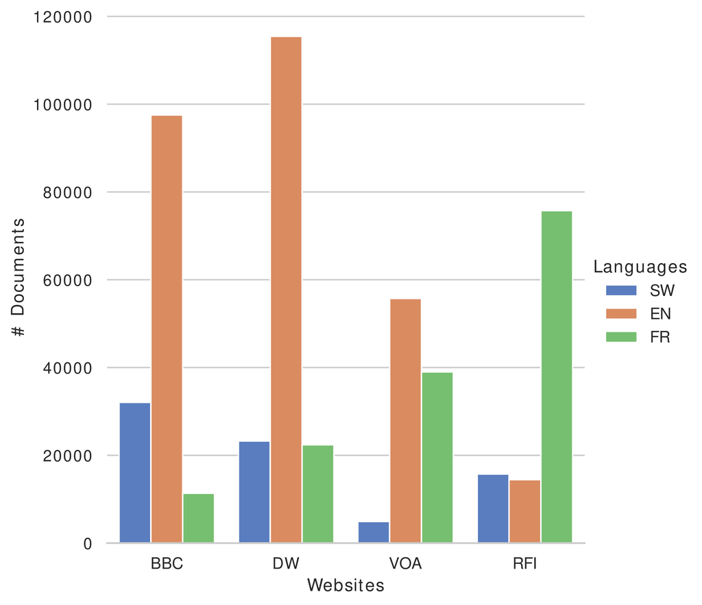

Fig 1. Total number of documents across 4 majors news publishers}

|  |  | # Documents | Average headline length (words) | Average document length (words) |
| --- | --- | --- | --- | --- |
|  | EN | 97532 | 22.30 | 497.21 |
| BBC | FR | 11356 | 24.71 | 228.63 |
|  | SW | 32056 | 24.065 | 189.03 |
|  | EN | 14455 | 39.00 | 387.76 |
| RFI | FR | 75741 | 61.97 | 377.75 |
|  | SW | 15737 | 32.75 | 183.36 |
|  | EN | 115450 | 32.19 | 605.71 |
| DW | FR | 22403 | 32.76 | 310.98 |
|  | SW | 23260 | 27.72 | 385.81 |
|  | EN | 55733 | 47.86 | 440.67 |
| VOA | FR | 38999 | 34.39 | 788.89 |
|  | SW | 4929 | 25.55 | 189.86 |

Table 1. Documents numbers and their facts across 4 majors news publishers

## II. Cross-lingual

Given the challenging nature of acquiring cross-lingual datasets due to the discrepancy in the source and target languages. Inspired by [3] work, we utilized the forward translation as a method for acquiring cross-lingual targets from the previously gathered multilingual dataset. We leveraged existing models (https://huggingface.co/Helsinki-NLP) (models: opus-mt- en-fr, en-swc, fr-en, fr-swc, swc-en, swc-fr)} available in the transformer library [4] as machine translation service to construct a final cross-lingual dataset by relying on the forward translation to acquire the corresponding cross-lingual target for the source document. The monolingual target is translated by the aforementioned models from one language to another (forward translation). The following figure depicts the forward translation operation.

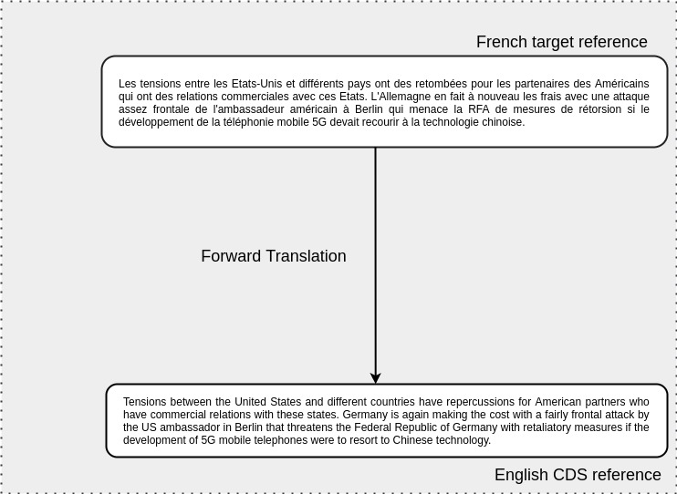

Fig 2. Overview diagram illustrating the forward translation operation to acquire cross-lingual target. The monolingual target is translated from one language to another by leveraging the aforesaid machine translation system

We have used the forward translation operation for most of our datasets. However, because current machine translation system may behave poorly for some examples, We can extend the previously-mentioned operation with a back translation whereby the CDS reference is translated back to the same language as a monolingual target. The combination of these two operations is known as round-trip translation (RRT). The back translation is quintessential to doing a filtering operation by leveraging the ROUGE[5] score between the round-trip translated reference and the monolingual target reference. In our truncated experiment given the context, the results with and without this filtering were on par for the Swahili source document. Further investigation may be needed to ascertain the use of that operation in the complete RRT for the French and English source documents.

## III. Conclusion

We have gone through several steps required to create a cross-lingual dataset for document summarization, we start with the curation of a monolingual corpus from webpages then leverage a machine translation model to acquire a cross-lingual target from a monolingual summary.

## IV. References

1. Shashi Narayan and Shay B. Cohen and Mirella Lapata. Don't Give Me the Details, Just the Summary! Topic-Aware Convolutional Neural Networks for Extreme Summarization. ArXiv, 2018
2. Karl Moritz Hermann and Tomáš Kočiský and Edward Grefenstette and Lasse Espeholt and Will Kay and Mustafa Suleyman and Phil Blunsom. Teaching Machines to Read and Comprehend. In Advances in Neural Information Processing Systems (NIPS), 2015
3. Guillaume Lample and Alexis Conneau and Ludovic Denoyer and Marc'Aurelio Ranzato. Unsupervised Machine Translation Using Monolingual Corpora Only. International Conference on Learning Representation, 2018
4. Thomas Wolf and Lysandre Debut and Victor Sanh and Julien Chaumond and Clement Delangue and Anthony Moi and Pierric Cistac and Tim Rault and Rémi Louf and Morgan Funtowicz and Joe Davison and Sam Shleifer and Patrick von Platen and Clara Ma and Yacine Jernite and Julien Plu and Canwen Xu and Teven Le Scao and Sylvain Gugger and Mariama Drame and Quentin Lhoest and Alexander M. Rush. HuggingFace's Transformers: State-of-the-art Natural Language Processing. Proceedings of the 2020 Conference on Empirical Methods in Natural Language Processing: System Demonstrations, 2020
5. Jung-Min Lim and In-Su Kang and Jong-Hyeok Lee. Multi-document summarization using cross-language texts.In Proceedings of the Fourth NTCIR Workshop on Research in Information Access echnologies Information Retrieval, Question Answering and Summarization (NTCIR), 2004